# Bayesian Principles applied to Legislative Votes

```r
library(tidyverse)
library(rethinking)
source("../../../GitHub/ARM2_final/scripts/leg_data.R")
```

```
here() starts at /Users/corban_nemeth/GitHub/ARM2_final
```

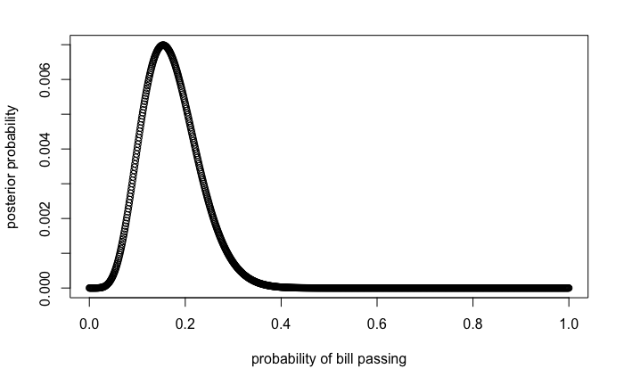

```r
#for one sample legislator, Senator Hunt
huntbills <- sponsor_record %>%
  filter(original_sponsor == "Hunt")
passed <- sum(huntbills$`1`)
totbills <- sum(huntbills$tot_bills)
p_grid <- seq( from=0 , to=1 , length.out=1000 )
prob_p <- rep( 1 , 1000 )
prob_data <- dbinom( passed , size=totbills , prob=p_grid )
posterior <- prob_data * prob_p
posterior <- posterior / sum(posterior)
plot( p_grid , posterior , type="b" ,
    xlab="probability of bill passing" , ylab="posterior probability" )
```

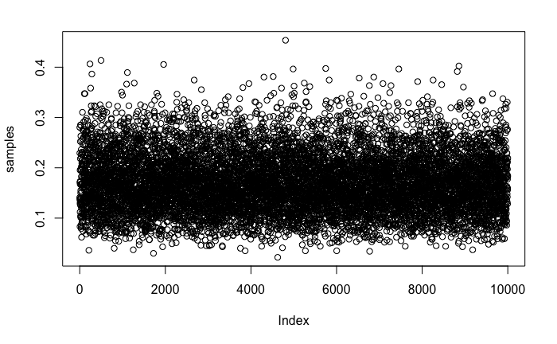

```r
#Sampling from the posterior
samples <- sample( p_grid , prob=posterior , size=1e4 , replace=TRUE )
plot(samples)
```

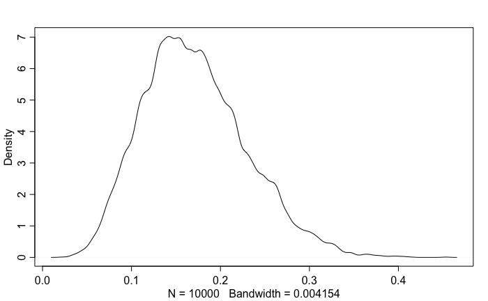

```r
dens( samples ) #fn from rethinking
```

Using sampling to summarize the posterior

These simple questions can be usefully divided into questions about (1) intervals of defined boundaries, (2) questions about intervals of defined probability mass, and (3) questions about point estimates. We’ll see how to approach these questions using samples from the posterior.

```r
 # add up posterior probability where p < 0.19
sum( posterior[ p_grid < 0.19 ] ) #this is directly from grid approx. and won't scale
```

```
[1] 0.6564534
```

```r
#posterior probability using samples
sum( samples < 0.19 ) / 1e4 #frequency of sampled parameter values below 0.19
```

```
[1] 0.6535
```

```r
#between two points
sum( samples > 0.1 & samples < 0.2 ) / 1e4
```

```
[1] 0.6122
```

It is more common to see scientific journals reporting an interval of defined mass, usually known as a confidence interval. An interval of posterior probability, such as the ones we are working with, may instead be called a credible interval, although the terms may also be used interchangeably, in the usual polysemy that arises when commonplace words are used in technical definitions. – basically inverse of above, defining % and finding the range

```r
#lower 80 percent range
quantile( samples , 0.8 )
```

```
      80%
0.2192192
```

```r
#middle 80 percent range *percentile interval*
quantile( samples , c( 0.1 , 0.9 ) )
```

```
      10%       90%
0.1001001 0.2502503
```

```r
#PI func from rethinking
 PI( samples , prob=0.5 )
```

```
      25%       75%
0.1291291 0.2082082
```

```r
#highest posterior density interval (HPDI) contains the narrowest possible band of specified probability mass
 HPDI( samples , prob=0.5 )
```

```
     |0.5      0.5|
0.1251251 0.2012012
```

Overall, if the choice of interval type makes a big difference, then you shouldn’t be us- ing intervals to summarize the posterior. Remember, the entire posterior distribution is the Bayesian “estimate.” It summarizes the relative plausibilities of each possible value of the parameter. Intervals of the distribution are just helpful for summarizing it. If choice of in- terval leads to different inferences, then you’d be better off just plotting the entire posterior distribution.

a maximum a posteriori (MAP) estimate. You can easily compute the MAP in this example:

```r
 p_grid[ which.max(posterior) ] #for grid approximation
```

```
[1] 0.1541542
```

```r
 chainmode( samples , adj=0.01 ) #using mode (same as MAP)
```

```
[1] 0.1663129
```

```r
 mean( samples )
```

```
[1] 0.1712767
```

```r
median( samples )
```

```
[1] 0.1661662
```

One principled way to go beyond using the entire posterior as the estimate is to choose a loss function. A loss function is a rule that tells you the cost associated with using any particular point estimate. While statisticians and game theorists have long been interested in loss functions, and how Bayesian inference supports them, scientists hardly ever use them explicitly. The key insight is that different loss functions imply different point estimates. Here’s an example to help us work through the procedure. Suppose I offer you a bet. Tell me which value of p, the proportion of water on the Earth, you think is correct. I will pay you $100, if you get it exactly right. But I will subtract money from your gain, proportional to the distance of your decision from the correct value. Precisely, your loss is proportional to the absolute value of d − p, where d is your decision and p is the correct answer. We could change the precise dollar values involved, without changing the important aspects of this problem. What matters is that the loss is proportional to the distance of your decision from the true value. Now once you have the posterior distribution in hand, how should you use it to maxi- mize your expected winnings? It turns out that the parameter value that maximizes expected winnings (minimizes expected loss) is the median of the posterior distribution.

```r
#loss fn
 loss <- sapply( p_grid , function(d) sum( posterior*abs( d - p_grid ) ) )
  p_grid[ which.min(loss) ] #same as median in this case
```

```
[1] 0.1651652
```

Different loss functions nominate different point estimates. The two most common examples are the absolute loss as above, which leads to the median as the point estimate, and the quadratic loss (d − p)2, which leads to the posterior mean (mean(samples)) as the point estimate. When the posterior distribution is symmetrical and normal-looking, then the median and mean converge to the same point, which relaxes some anxiety we might have about choosing a loss function. For the original globe tossing data (6 waters in 9 tosses), for example, the mean and median are barely different. In principle, though, the details of the applied context may demand a rather unique loss function. Consider a practical example like deciding whether or not to order an evacuation, based upon an estimate of hurricane wind speed. Damage to life and property increases very rapidly as wind speed increases. There are also costs to ordering an evacuation when none is needed, but these are much smaller. Therefore the implied loss function is highly asymmetric, rising sharply as true wind speed exceeds our guess, but rising only slowly as true wind speed falls below our guess. In this context, the optimal point estimate would tend to be larger than posterior mean or median. Moreover, the real issue is whether or not to order an evacuation, and so producing a point estimate of wind speed may not be necessary at all.

Bayesian models are always generative, capable of simulating predictions. Many non-Bayesian models are also generative, but many are not. We will call such simulated data dummy data, to indicate that it is a stand-in for actual data. With the globe tossing model, the dummy data arises from a binomial likelihood:

```r
#dummy data
 dbinom( 0:2 , size=2 , prob=0.2 ) #simulating data for 2 bills, with true prob = 0.2. This means that with 2 trials, there is a 64% chance of no bills passing, a 32% chance of 1 bill passing, and a 4% chance of both bills passing if the true prob is 20%
```

```
[1] 0.64 0.32 0.04
```

```r
#now to simulate observations using the above probabilities. 2 bills, 1e5 times, how many pass each trial?
dummy_data <- rbinom(1e5 , size=2 , prob=0.2)
table(dummy_data)/1e5
```

```
dummy_data
      0       1       2
0.63825 0.32217 0.03958
```

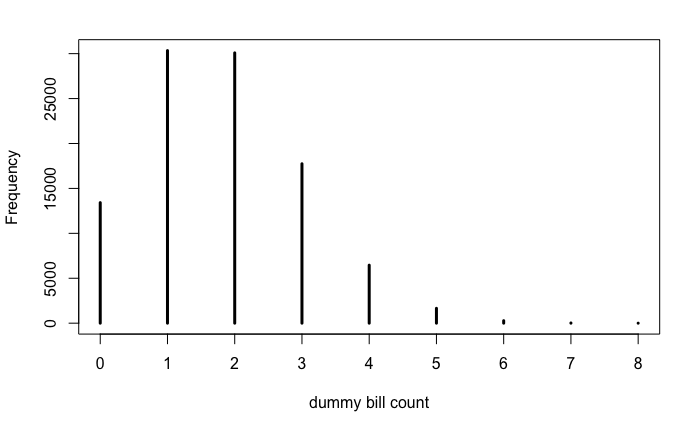

```r
#now simulate trials with 9 bills introduced
dummy_data <- rbinom( 1e5 , size=9 , prob=0.2 )
simplehist( dummy_data , xlab="dummy bill count" )
```

We’d like to propagate the parameter uncertainty—carry it forward—as we evaluate the implied predictions. All that is required is averaging over the posterior density for p, while computing the predictions. For each possible value of the parameter p, there is an implied distribution of outcomes. So if you were to compute the sampling distribution of outcomes at each value of p, then you could average all of these prediction distributions together, using the posterior probabilities of each value of p, to get a posterior predictive distribution.

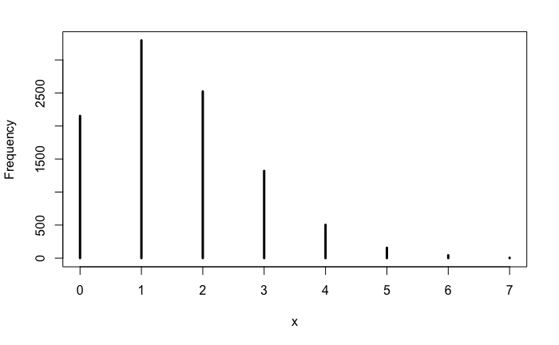

```r
#simulate predicted observations for a single value of p, for 9 bills, predictions stored as bills passed
 w <- rbinom( 1e4 , size=9 , prob=0.2 )

#to propogate parameter uncertainty, replace the value 0.2 with samples from the posterior
w <- rbinom( 1e4 , size=9 , prob=samples ) #Using Sen. Hunt's true data of bill passage for 9 bills
simplehist(w)
```

## Chapter Four

Linear regression is the geocentric model of applied statistics. By “linear regression,” we will mean a family of simple statistical golems that attempt to learn about the mean and variance of some measurement, using an additive combination of other measurements. Like geocentrism, linear regression can usefully describe a very large variety of natural phenom- ena. Like geocentrism, linear regression is a descriptive model that corresponds to many different process models. If we read its structure too literally, we’re likely to make mistakes. But used wisely, these little linear golems continue to be useful.

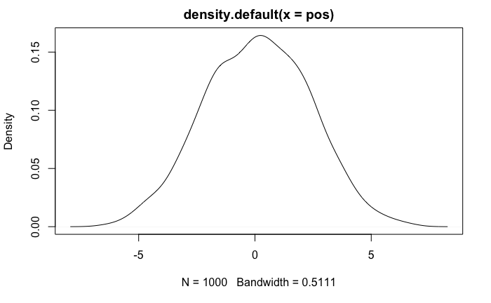

```r
#random walk, 16 trials, e.g. coin flip. Heads equals forwards one step, tails equals back one step. Normal!
 pos <- replicate( 1000 , sum( runif(16,-1,1) ) )
plot(density(pos))
```

Any process that adds together random values from the same distribution converges to a normal.

```r
# normal by multiplication
 prod( 1 + runif(12,0,0.1) )
```

```
[1] 1.904258
```

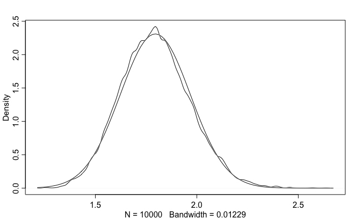

```r
growth <- replicate( 10000 , prod( 1 + runif(12,0,0.1) ) )
dens( growth , norm.comp=TRUE )
```

small effects that multiply together are approximately additive, and so they also tend to stabilize on Gaussian distributions

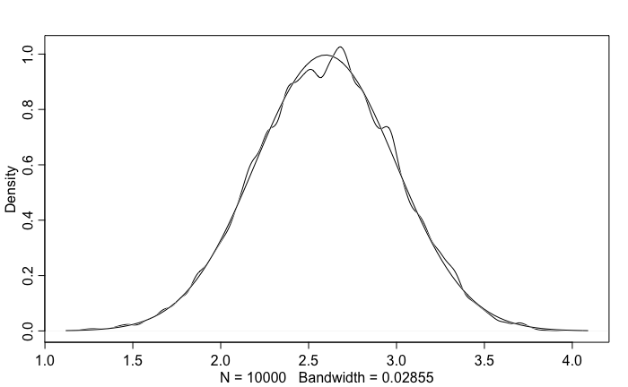

```r
#logs of large number multiples also converge to normal
log.big <- replicate(10000 , log(prod(1 +runif(12,0,0.5))))
dens( log.big , norm.comp=TRUE )
```

Ontological justification. The world is full of Gaussian distributions, approxi- mately. As a mathematical idealization, we’re never going to experience a perfect Gaussian distribution. But it is a widespread pattern, appearing again and again at different scales and in different domains. Measurement errors, variations in growth, and the velocities of molecules all tend towards Gaussian distributions. These processes do this because at their heart, these processes add together fluctuations. And repeatedly adding finite fluctuations results in a distribution of sums that have shed all information about the underlying process, aside from mean and spread.

That is to say that the Gaussian distribution is the most natural expression of our state of ignorance, because if all we are willing to assume is that a measure has finite variance, the Gaussian distribution is the shape that can be realized in the largest number of ways and does not introduce any new assumptions. It is the least surprising and least informative assumption to make.

## Definitions

models as mappings of one set of variables through a probability distribution onto another set of variables. Fundamentally, these models define the ways values of some variables can arise, given values of other variables

For leg data: w = observed count of bills passed W ~ Binomial(N, p) #model used in bayes theorem p ~ Uniform(0,1) #prior, ~ means stochastic (aka not deterministic)

The count W is distributed binomially with sample size N and probability p. The prior for p is assumed to be uniform between zero and one.

We know the binomial distribution assumes that each sample (globe toss) is independent of the others, and so we also know that the model assumes that sample points are independent of one another.

## Chapter 4

```r
library(rethinking)
data(Howell1)
d <- Howell1
```

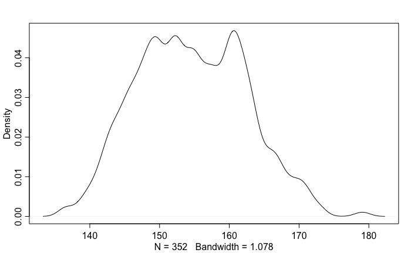

```r
#filter to age over 18
d2 <- d[ d$age >= 18 , ]
dens(d2$height)
```

```r
#follow along with leg data
sponsor_record$`1`
```

```
  [1]  1  1  1  2  2  2  5  0  5  4  4  4  1  1  1  5  1  9  6  3  1  4  5  5  0  2 11  6  3  1  0  3  1  1  9  3  2  4  6  0  1  6  2  1  1
 [46]  3  2  5  1  4  1  3  1  1  6  1  4  8 10  6  6  5  2  3  0  2  5  3  4  7  4  5  3  4  1  0  6  2  2  3  7  2  5  1  3  4  2  4  5  5
 [91]  3  8  4  5  2  1  4  5  4  7  4  6  9  0  3  6  2  3  3  0  1  3  0  0  3  0  3  0  3  4  3  1  5  4  0  8  2  2  5  2  2  1  2  3  2
[136]  5  2  4  5  5  3  2  1  0  6
```

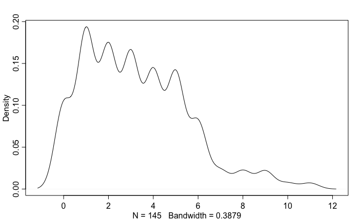

```r
dens(sponsor_record$`1`)
```

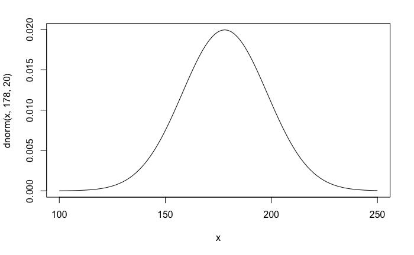

```r
#plot priors for height data
#hsub(i) ~ Normal(mean, std.dev)
#mean ~Normal (178, 20)
#std dev ~ Uniform (0,50)
 curve( dnorm( x , 178 , 20 ) , from=100 , to=250 ) #mean height
```

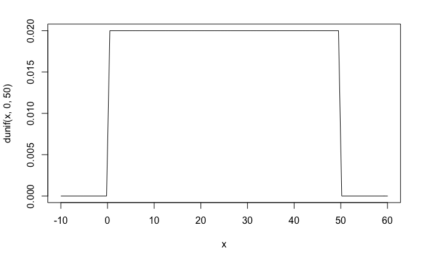

```r
 curve( dunif( x , 0 , 50 ) , from=-10 , to=60 ) #standard deviation prior
```

prior predictive simulations Once you’ve chosen priors for h, μ, and σ, these imply a joint prior distribution of individual heights. By simulating from this distribution, you can see what your choices imply about observable height. This helps you diagnose bad choices. Lots of conventional choices are indeed bad ones, and we’ll be able to see this by conducting prior predictive sim- ulations.

Sample from prior to test distribution

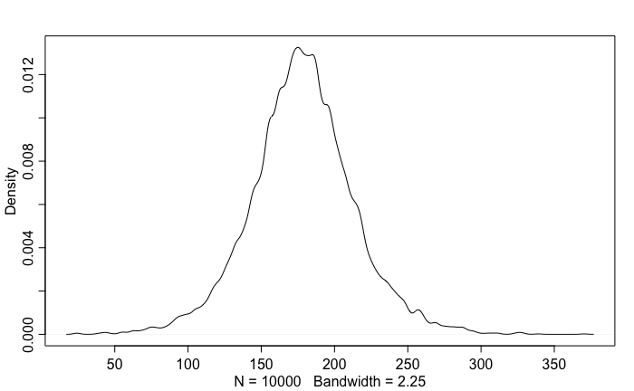

```r
#distributions of distributions
sample_mu <- rnorm( 1e4 , 178 , 20 )
sample_sigma <- runif( 1e4 , 0 , 50 )
prior_h <- rnorm( 1e4 , sample_mu , sample_sigma )
dens( prior_h )
```

## Grid approximation of the posterior distribution

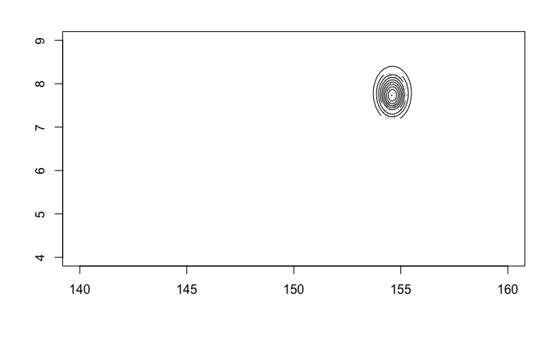

```r
#this is laborious and computationally expensive and only used for an example
mu.list <- seq( from=140, to=160 , length.out=200 )
sigma.list <- seq( from=4 , to=9 , length.out=200 )
post <- expand.grid( mu=mu.list , sigma=sigma.list )
post$LL <- sapply( 1:nrow(post) , function(i) sum( dnorm(
                d2$height ,
                mean=post$mu[i] ,
                sd=post$sigma[i] ,
                log=TRUE ) ) )
post$prod <- post$LL + dnorm( post$mu , 178 , 20 , TRUE ) +
    dunif( post$sigma , 0 , 50 , TRUE )
post$prob <- exp( post$prod - max(post$prod) )
contour_xyz( post$mu , post$sigma , post$prob )
```

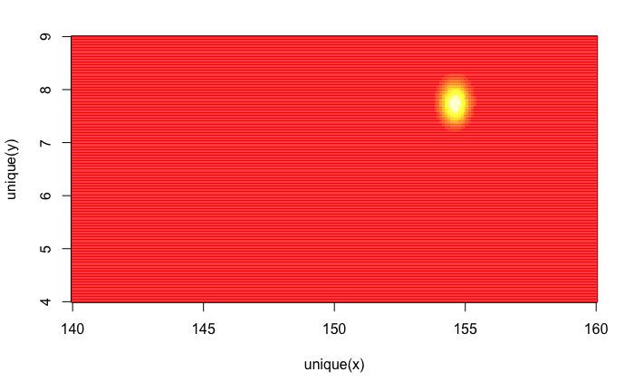

```r
image_xyz( post$mu , post$sigma , post$prob ) #represents height and std dev
```

Sampling from the posterior

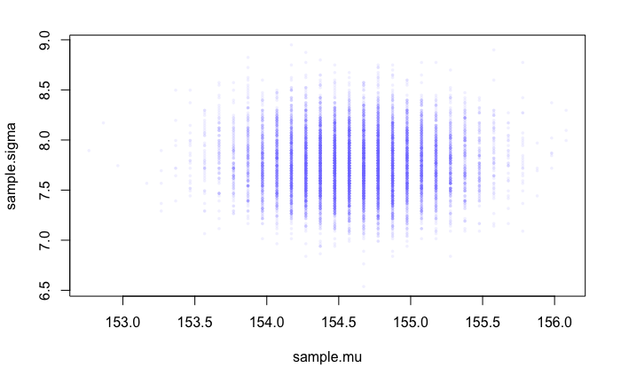

```r
sample.rows <- sample( 1:nrow(post) , size=1e4 , replace=TRUE , #sampling 10000 rows from posterior distribution to get corresponding mean and std dev values, then filtering the corresponding posterior values
    prob=post$prob )
sample.mu <- post$mu[ sample.rows ]
sample.sigma <- post$sigma[ sample.rows ]
plot( sample.mu , sample.sigma , cex=0.5 , pch=16 , col=col.alpha(rangi2,0.1) )
```

Now that you have these samples, you can describe the distribution of confidence in each combination of μ and σ by summarizing the samples. Think of them like data and describe them, just like in Chapter 3. For example, to characterize the shapes of the marginal posterior densities of μ and σ, all we need to do is: The jargon “marginal” here means “averaging over the other parameters.”

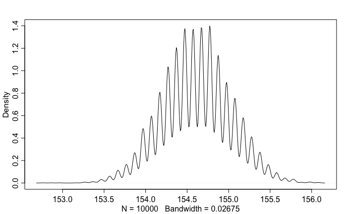

```r
dens( sample.mu )
```

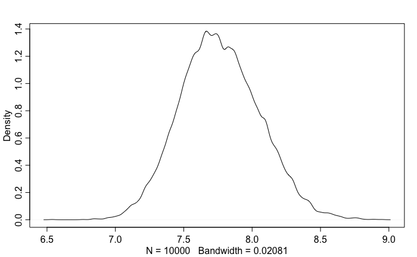

```r
dens( sample.sigma )
```

```r
#HPDI
HPDI( sample.mu )
```

```
   |0.89    0.89|
153.8693 155.1759
```

```r
HPDI( sample.sigma )
```

```
   |0.89    0.89|
7.341709 8.246231
```

## Posterior Distribution with Quadratic Approximation

Our interest in quadratic approximation, recall, is as a handy way to quickly make inferences about the shape of the posterior. The posterior’s peak will lie at the maximum a posteriori estimate (MAP), and we can get a useful image of the posterior’s shape by using the quadratic approximation of the posterior distribution at this peak.

```r
library(rethinking)
data(Howell1)
d <- Howell1
d2 <- d[ d$age >= 18 , ]
```

hi ∼ Normal(μ, σ) μ ∼ Normal(178, 20) σ ∼ Uniform(0, 50) height ~ dnorm(mu,sigma) mu ~ dnorm(178,20) sigma ~ dunif(0,50)

```r
#make list of above
flist <- alist(
    height ~ dnorm( mu , sigma ) ,
    mu ~ dnorm( 178 , 20 ) ,
    sigma ~ dunif( 0 , 50 )
)
#fit model to data
 m4.1 <- quap( flist , data=d2 )

 #examine model
 precis(m4.1)
```

|  | mean | sd | 5.5% | 94.5% |
| --- | --- | --- | --- | --- |
| mu | 154.61 | 0.41 | 153.95 | 155.27 |
| sigma | 7.73 | 0.29 | 7.27 | 8.20 |

```r
#changing to a very narrow prior for mean height
m4.2 <- quap(
    alist(
        height ~ dnorm( mu , sigma ) ,
        mu ~ dnorm( 178 , 0.1 ) ,
        sigma ~ dunif( 0 , 50 )
    ) , data=d2 )
precis( m4.2 )
```

|  | mean | sd | 5.5% | 94.5% |
| --- | --- | --- | --- | --- |
| mu | 177.86 | 0.10 | 177.70 | 178.02 |
| sigma | 24.51 | 0.93 | 23.02 | 25.99 |

when R constructs a quadratic approximation, it calculates not only standard deviations for all parameters, but also the covariances among all pairs of param- eters. Just like a mean and standard deviation (or its square, a variance) are sufficient to describe a one-dimensional Gaussian distribution, a list of means and a matrix of variances and covariances are sufficient to describe a multi-dimensional Gaussian distribution.

```r
#variance and covariance for m41
vcov( m4.1 ) #variance-covariance matrix
```

```
                mu        sigma
mu    0.1697381931 0.0002184397
sigma 0.0002184397 0.0849040475
```

```r
#decomposition of var-covar
diag( vcov( m4.1 ) ) #list of variances (sqrt to get st dev from precip)
```

```
        mu      sigma
0.16973819 0.08490405
```

```r
cov2cor( vcov( m4.1 ) ) #relation of mean to st dev
```

```
               mu       sigma
mu    1.000000000 0.001819607
sigma 0.001819607 1.000000000
```

```r
#drawing samples from the multidemensional posterior
library(rethinking)
post <- extract.samples( m4.1 , n=1e4 )
head(post)
```

|  | mu | sigma |
| --- | --- | --- |
| 1 | 154.7537 | 7.807466 |
| 2 | 154.5956 | 7.569702 |
| 3 | 154.2824 | 7.523121 |
| 4 | 154.5381 | 7.623981 |
| 5 | 154.7006 | 7.174331 |
| 6 | 154.6420 | 7.873897 |

```r
precis(post) #compare to...
```

```
quap posterior: 10000 samples from m4.1
```

|  | mean | sd | 5.5% | 94.5% | histogram |
| --- | --- | --- | --- | --- | --- |
| mu | 154.61 | 0.41 | 153.94 | 155.26 | ▁▁▁▅▇▂▁▁ |
| sigma | 7.73 | 0.29 | 7.27 | 8.21 | ▁▁▁▁▂▅▇▇▃▁▁▁▁ |

```r
precis(m4.1)
```

|  | mean | sd | 5.5% | 94.5% |
| --- | --- | --- | --- | --- |
| mu | 154.61 | 0.41 | 153.95 | 155.27 |
| sigma | 7.73 | 0.29 | 7.27 | 8.20 |

once you add a predictor variable to your model, covariance will matter a lot.

### Adding a predictor

What we’ve done above is a Gaussian model of height in a population of adults. But it doesn’t really have the usual feel of “regression” to it. Typically, we are interested in modeling how an outcome is related to some predictor variable. And by including a predictor variable in a particular way, we’ll have linear regression. So now let’s look at how height in these Kalahari foragers covaries with weight. This isn’t the most thrilling scientific question, I know. But it is an easy relationship to start with, and if it seems dull, it’s because you don’t have a theory about growth and life history in mind. If you did, it would be thrilling. We’ll try later on to add some of that thrill.

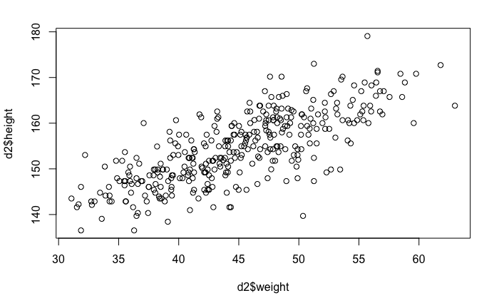

```r
plot( d2$height ~ d2$weight )
```